# Shopper & shopkeeper survey methodology

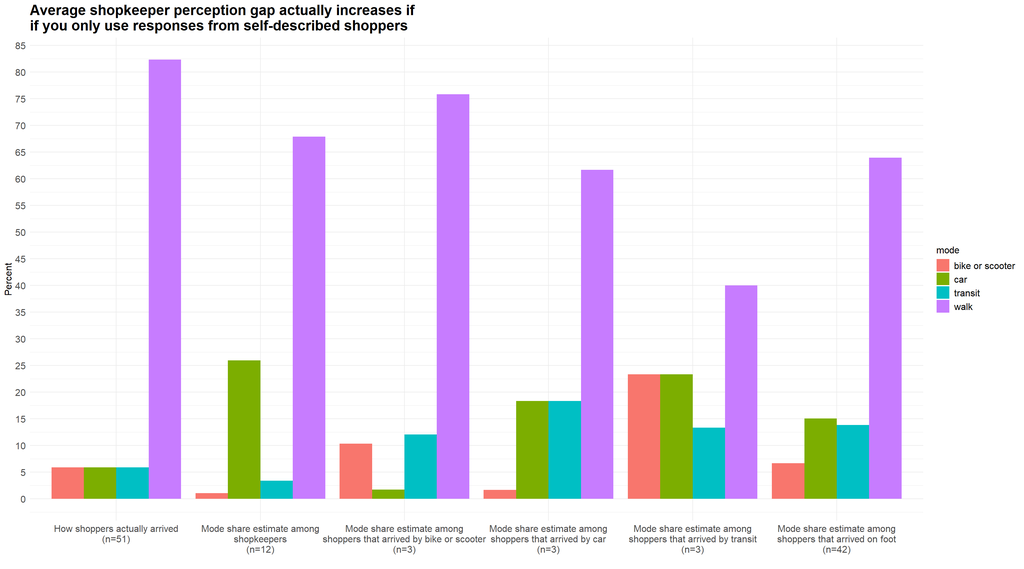

```r
make_modes_and_perceptions_graph(psd[psd$date !='July 19 2024' & psd$do_they_shop_on_this_strip == 'yes',],
                                 skd, font_size=12, main_graph = FALSE,
                                 title='Average shopkeeper perception gap actually increases if\nif you only use responses from self-described shoppers')[[1]]
```

The N values for the respondents that drive, take transit, and bike are too small in the subsample below to mean anything, but the number of walkers relative to teh shopkeeper perception actually grows again.

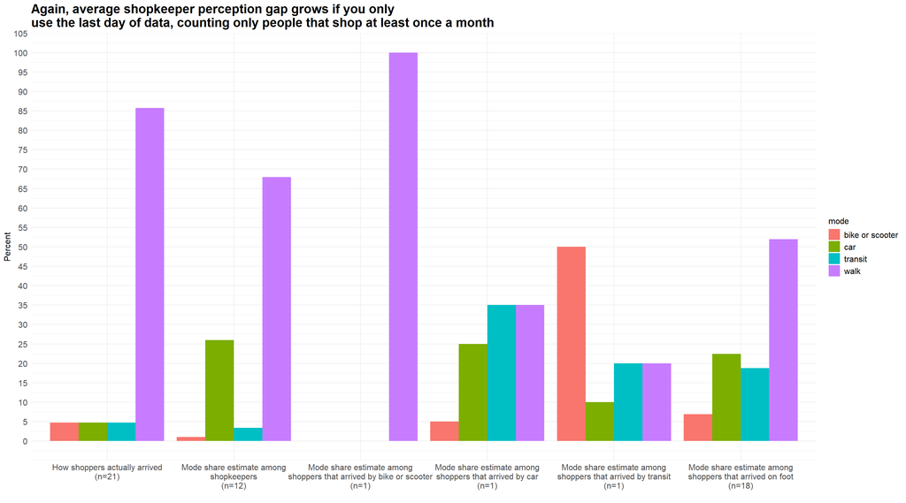

```r
make_modes_and_perceptions_graph(psd[psd$date =='July 26 2024' & psd$do_they_shop_on_this_strip == 'yes',],
                                 skd, font_size=12, main_graph = FALSE,
                                 title='Again, average shopkeeper perception gap grows if you only\nuse the last day of data, counting only people that shop at least once a month')[[1]]
```

We can also just look at the results if we subset to look at each day’s worth of data individually.

Analyzing every day individually, shopkeepers’ average estimate of the share of their customers is only accurate on July 26. This was the day that saw the fewest walkers, and my anecdotal hunch is that this might be because people are more likely to drive / take uber to Namak & Perry’s, since those are kind of “destination restaurants” (as opposed to Yes, for example). And I was standing outside Namak and Perry’s all night on the 26th, a Friday, so I suspect this was the high-water mark for driving, and the lower-bound for walking. (The staff person at Namak estimated that only 40% of customers walk).

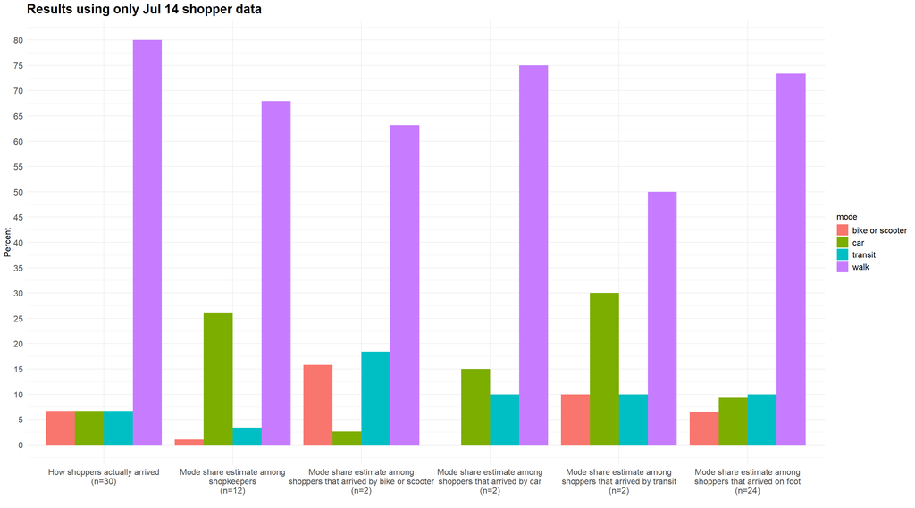

```r
p1 <- make_modes_and_perceptions_graph(psd[psd$date =='July 14 2024',],
                                 skd, font_size=12, main_graph = FALSE,
                                 title='Results using only Jul 14 shopper data')
p2 <- make_modes_and_perceptions_graph(psd[psd$date =='July 15 2024',],
                                 skd, font_size=12, main_graph = FALSE,
                                 title='Results using only Jul 15 shopper data')
p3 <- make_modes_and_perceptions_graph(psd[psd$date =='July 19 2024',],
                                 skd, font_size=12, main_graph = FALSE,
                                 title='Results using only Jul 19 shopper data')
p4 <- make_modes_and_perceptions_graph(psd[psd$date =='July 26 2024',],
                                 skd, font_size=12, main_graph = FALSE,
                                 title='Results using only Jul 26 shopper data')

p1[[1]]
```

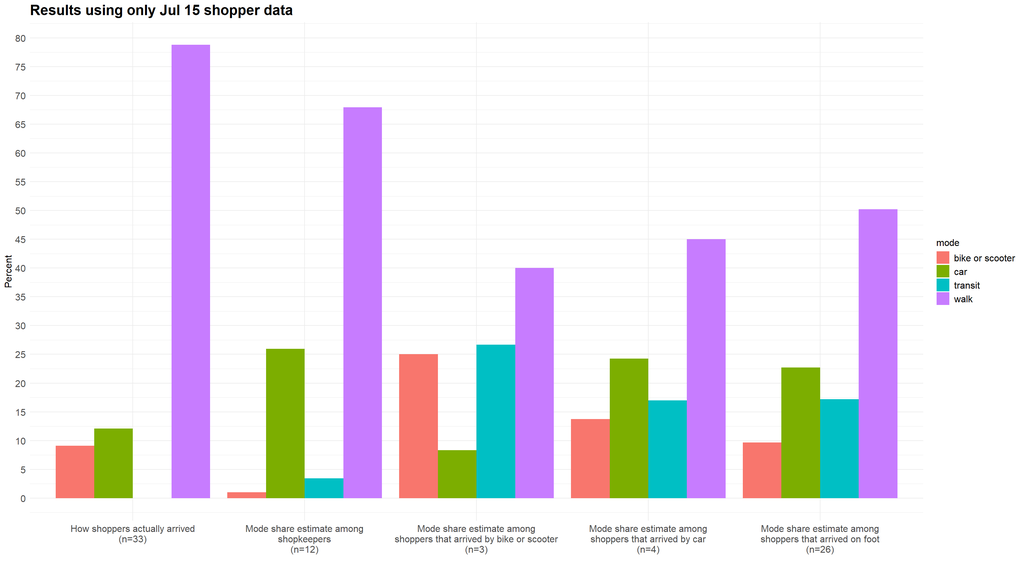

```r
p2[[1]]
```

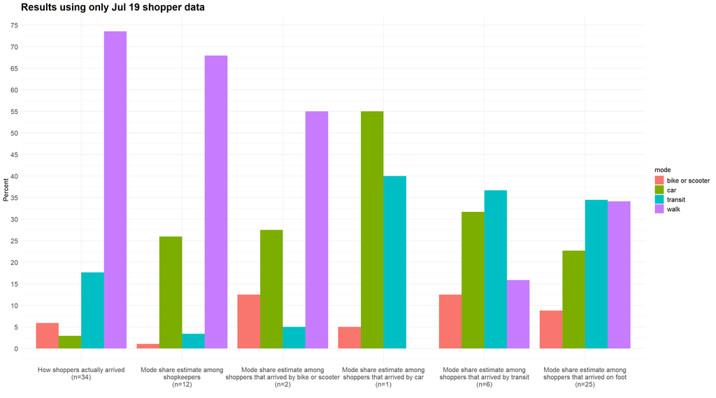

```r
p3[[1]]
```

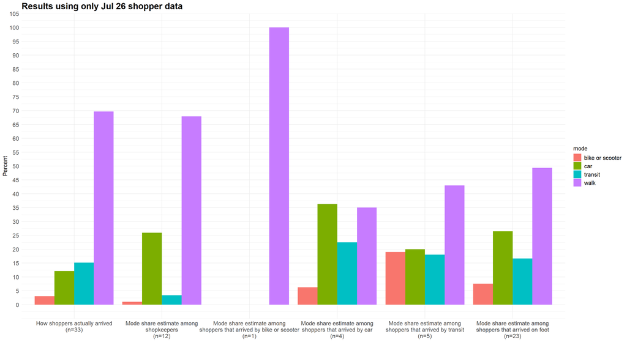

```r
p4[[1]]
```

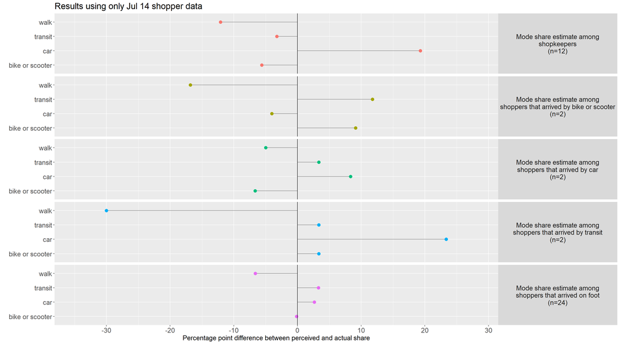

```r
make_dotplot(p1[[2]], title = 'Results using only Jul 14 shopper data')
```

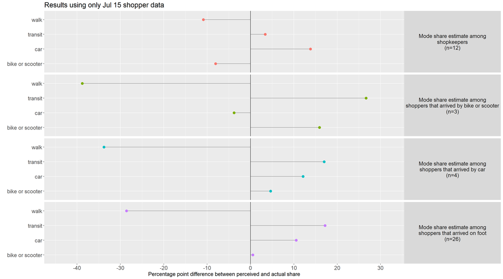

```r
make_dotplot(p2[[2]], title = 'Results using only Jul 15 shopper data')
```

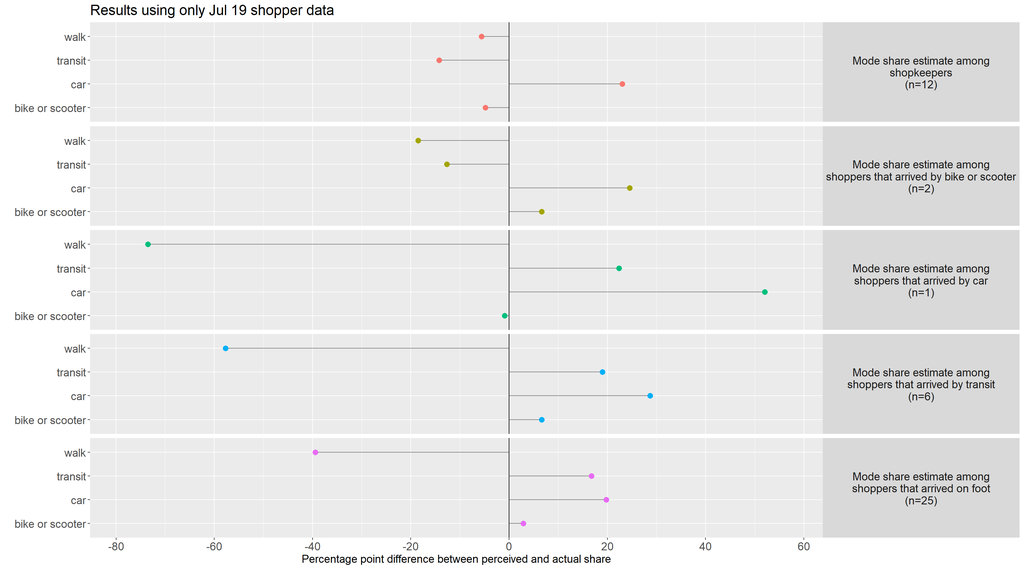

```r
make_dotplot(p3[[2]], title = 'Results using only Jul 19 shopper data')
```

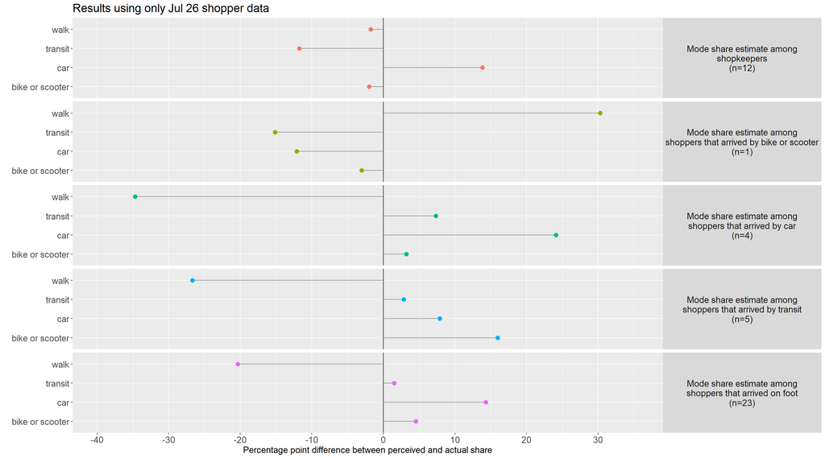

```r
make_dotplot(p4[[2]], title = 'Results using only Jul 26 shopper data')
```

What if we only look at data from the first day, comparing the responses from people going into So’s Your Mom with the responses from the business people in the shop?

Below are the raw responses. There’s a bit of an odd data hiccup in that one of the staff estimated that 80% of customers walk, but didn’t provide a share for anything except walking. If you just include the one complete response, the shopkeeper overestimated both walking and driving.

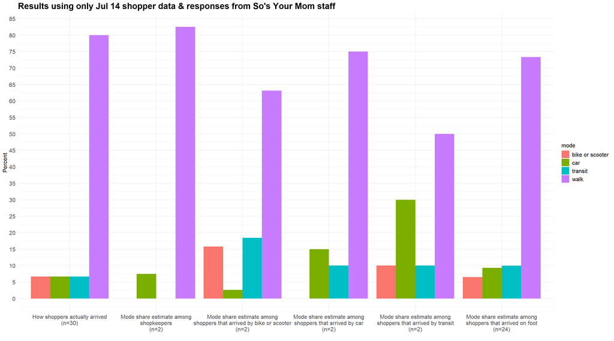

```
##
## [[2]]
## # A tibble: 24 × 4
## # Groups:   persons_method_of_travel [6]
##    persons_method_of_travel                                                     mode            percent max_percent
##    <chr>                                                                        <chr>             <dbl>       <dbl>
##  1 "Mode share estimate among\nshoppers that arrived by bike or scooter\n(n=2)" walk              63.2         63.2
##  2 "Mode share estimate among\nshoppers that arrived by bike or scooter\n(n=2)" car                2.63        63.2
##  3 "Mode share estimate among\nshoppers that arrived by bike or scooter\n(n=2)" bike or scooter   15.8         63.2
##  4 "Mode share estimate among\nshoppers that arrived by bike or scooter\n(n=2)" transit           18.4         63.2
##  5 "Mode share estimate among\nshoppers that arrived by car\n(n=2)"             walk              75           75
##  6 "Mode share estimate among\nshoppers that arrived by car\n(n=2)"             car               15           75
##  7 "Mode share estimate among\nshoppers that arrived by car\n(n=2)"             bike or scooter    0           75
##  8 "Mode share estimate among\nshoppers that arrived by car\n(n=2)"             transit           10           75
##  9 "Mode share estimate among\nshoppers that arrived by transit\n(n=2)"         walk              50           50
## 10 "Mode share estimate among\nshoppers that arrived by transit\n(n=2)"         car               30           50
## # ℹ 14 more rows
```

```r
make_modes_and_perceptions_graph(psd[psd$date =='July 14 2024',],
                                 skd[skd$store == "Sos your mom" , ], font_size=12, main_graph = FALSE,
                                 title="Results using only Jul 14 shopper data & responses from So's Your Mom staff")
```

If we just take that 20% that was unspecified in the 2nd shopkeeper’s response and distribute it equally among the other options (biking/scootering, driving, and transit), we see results that are similar-ish to the main results. The shopkeepers actually over-estimate walking, but, like the other shopkeepers on average, they over-estimate car-use while underestimating biking, scootering, and transit-use.

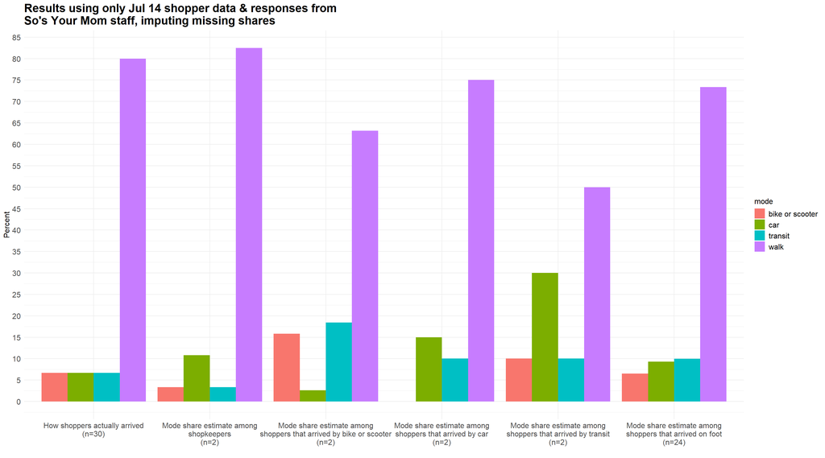

```
##
## [[2]]
## # A tibble: 24 × 4
## # Groups:   persons_method_of_travel [6]
##    persons_method_of_travel                                                     mode            percent max_percent
##    <chr>                                                                        <chr>             <dbl>       <dbl>
##  1 "Mode share estimate among\nshoppers that arrived by bike or scooter\n(n=2)" walk              63.2         63.2
##  2 "Mode share estimate among\nshoppers that arrived by bike or scooter\n(n=2)" car                2.63        63.2
##  3 "Mode share estimate among\nshoppers that arrived by bike or scooter\n(n=2)" bike or scooter   15.8         63.2
##  4 "Mode share estimate among\nshoppers that arrived by bike or scooter\n(n=2)" transit           18.4         63.2
##  5 "Mode share estimate among\nshoppers that arrived by car\n(n=2)"             walk              75           75
##  6 "Mode share estimate among\nshoppers that arrived by car\n(n=2)"             car               15           75
##  7 "Mode share estimate among\nshoppers that arrived by car\n(n=2)"             bike or scooter    0           75
##  8 "Mode share estimate among\nshoppers that arrived by car\n(n=2)"             transit           10           75
##  9 "Mode share estimate among\nshoppers that arrived by transit\n(n=2)"         walk              50           50
## 10 "Mode share estimate among\nshoppers that arrived by transit\n(n=2)"         car               30           50
## # ℹ 14 more rows
```

```r
make_modes_and_perceptions_graph(psd[psd$date =='July 14 2024',],
                                 skd[skd$store == "Sos your mom" , ] %>%
                                 mutate(drive_est = ifelse(date=="July 27 2024", yes=20/3, no=drive_est),
                                        transit_est = ifelse(date=="July 27 2024", yes=20/3, no=transit_est),
                                        bike_scooter_est = ifelse(date=="July 27 2024", yes=20/3, no=bike_scooter_est)
                                        ) ,
                                 font_size=12, main_graph = FALSE,
                                 title="Results using only Jul 14 shopper data & responses from\nSo's Your Mom staff, imputing missing shares")
```

We can do something similar with the the responses from staff at Yes Organic Market and the data from survey days 2 and 3. While this isn’t an exact 1-to-1 comparison, relatively more customers were entering Yes on those survey days, because I was standing in front of the store.

This shows results that are consistent with the overall averages.

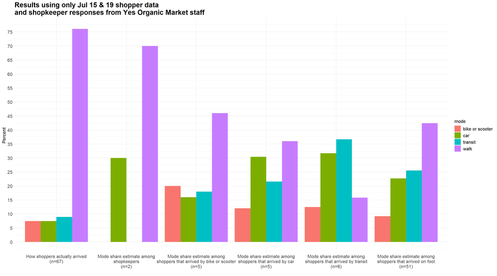

```
##
## [[2]]
## # A tibble: 24 × 4
## # Groups:   persons_method_of_travel [6]
##    persons_method_of_travel                                                     mode            percent max_percent
##    <chr>                                                                        <chr>             <dbl>       <dbl>
##  1 "Mode share estimate among\nshoppers that arrived by bike or scooter\n(n=5)" walk               46          46
##  2 "Mode share estimate among\nshoppers that arrived by bike or scooter\n(n=5)" car                16          46
##  3 "Mode share estimate among\nshoppers that arrived by bike or scooter\n(n=5)" bike or scooter    20          46
##  4 "Mode share estimate among\nshoppers that arrived by bike or scooter\n(n=5)" transit            18          46
##  5 "Mode share estimate among\nshoppers that arrived by car\n(n=5)"             walk               36          36
##  6 "Mode share estimate among\nshoppers that arrived by car\n(n=5)"             car                30.4        36
##  7 "Mode share estimate among\nshoppers that arrived by car\n(n=5)"             bike or scooter    12          36
##  8 "Mode share estimate among\nshoppers that arrived by car\n(n=5)"             transit            21.6        36
##  9 "Mode share estimate among\nshoppers that arrived by transit\n(n=6)"         walk               15.8        36.7
## 10 "Mode share estimate among\nshoppers that arrived by transit\n(n=6)"         car                31.7        36.7
## # ℹ 14 more rows
```

```r
make_modes_and_perceptions_graph(psd[psd$date =='July 15 2024' | psd$date =='July 19 2024',],
                                 skd[skd$store == "Yes Organic Market" , ], font_size=12, main_graph = FALSE,
                                 title='Results using only Jul 15 & 19 shopper data\nand shopkeeper responses from Yes Organic Market staff')
```

Ditto for the last day, when I was located in front of Namak: the shopkeepers appear to overestimate car-use and underestimate all other modes.

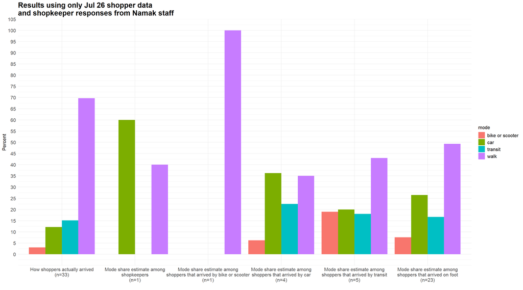

```
##
## [[2]]
## # A tibble: 24 × 4
## # Groups:   persons_method_of_travel [6]
##    persons_method_of_travel                                                     mode            percent max_percent
##    <chr>                                                                        <chr>             <dbl>       <dbl>
##  1 "Mode share estimate among\nshoppers that arrived by bike or scooter\n(n=1)" walk             100          100
##  2 "Mode share estimate among\nshoppers that arrived by bike or scooter\n(n=1)" car                0          100
##  3 "Mode share estimate among\nshoppers that arrived by bike or scooter\n(n=1)" bike or scooter    0          100
##  4 "Mode share estimate among\nshoppers that arrived by bike or scooter\n(n=1)" transit            0          100
##  5 "Mode share estimate among\nshoppers that arrived by car\n(n=4)"             walk              35           36.2
##  6 "Mode share estimate among\nshoppers that arrived by car\n(n=4)"             car               36.2         36.2
##  7 "Mode share estimate among\nshoppers that arrived by car\n(n=4)"             bike or scooter    6.25        36.2
##  8 "Mode share estimate among\nshoppers that arrived by car\n(n=4)"             transit           22.5         36.2
##  9 "Mode share estimate among\nshoppers that arrived by transit\n(n=5)"         walk              43           43
## 10 "Mode share estimate among\nshoppers that arrived by transit\n(n=5)"         car               20           43
## # ℹ 14 more rows
```

```r
make_modes_and_perceptions_graph(psd[psd$date =='July 26 2024',],
                                 skd[skd$store == "Namak" , ], font_size=12, main_graph = FALSE,
                                 title='Results using only Jul 26 shopper data\nand shopkeeper responses from Namak staff')
```

Overall, the general conclusions seem strong: on average, shopkeepers seem to underestimate walking (to varying degrees), overestimate car use, and underestimate transit use, and underestimate biking and scootering (even if some shopkeepers’ estimates are in line or above the true mode share values).

Finally, just as an aside, here is the shopping frequency by mode of transportation:

```r
psd %>%
  filter(date=='July 26 2024') %>%
  group_by(persons_method_of_travel) %>%
  summarize(mean_trips_per_month = round(mean(times_shop_on_this_strip_per_month, na.rm=T), 1),
            n=n()) %>%
  knitr::kable()
```

| persons_method_of_travel | mean_trips_per_month | n |
| --- | --- | --- |
| bike or scooter | 16.0 | 1 |
| car | 2.6 | 4 |
| transit | 4.8 | 5 |
| walk | 8.8 | 23 |

And the table below shows the percentage of respondents that report shopping at least once a month, and more than once a month:

```r
psd %>%
  filter(date == "July 26 2024") %>%
  mutate(at_least_once_a_month_flag = ifelse(test=times_shop_on_this_strip_per_month >= 1, yes=1, no=0),
         more_than_once_a_month_flag = ifelse(test=times_shop_on_this_strip_per_month > 1, yes=1, no=0)) %>%
  summarise(at_least_once_a_month_pct = round(mean(at_least_once_a_month_flag, na.rm=T)*100, 0),
         more_than_once_a_month_pct = round(mean(more_than_once_a_month_flag, na.rm=T)*100, 0)
         )
```

```
##   at_least_once_a_month_pct more_than_once_a_month_pct
## 1                        94                         64
```

```r
psd %>%
  filter(date == "July 26 2024") %>%
  mutate(at_least_once_a_month_flag = ifelse(test=times_shop_on_this_strip_per_month >= 1, yes=1, no=0),
         more_than_once_a_month_flag = ifelse(test=times_shop_on_this_strip_per_month > 1, yes=1, no=0)) %>%
  group_by(persons_method_of_travel) %>%
  summarise(
            at_least_once_a_month_pct = round(mean(at_least_once_a_month_flag)*100, 0),
            at_least_once_a_month_count = sum(at_least_once_a_month_flag),
            more_than_once_a_month_pct = round(mean(more_than_once_a_month_flag)*100, 0),
            more_than_once_a_month_count = sum(more_than_once_a_month_flag)
            ) %>%
  knitr::kable()
```

| persons_method_of_travel | at_least_once_a_month_pct | at_least_once_a_month_count | more_than_once_a_month_pct | more_than_once_a_month_count |
| --- | --- | --- | --- | --- |
| bike or scooter | 100 | 1 | 100 | 1 |
| car | 75 | 3 | 25 | 1 |
| transit | 100 | 5 | 20 | 1 |
| walk | 96 | 22 | 78 | 18 |